# **Market Basket Analysis**

## **Dataset**

**We'll use a dataset from a Brazilian eCommerce site ([olist.com](https://www.kaggle.com/olistbr/brazilian-ecommerce)) that is divided into three CSV files. The column definitions are as follows:**

`olist_order_items_dataset.csv`:

- `order_id`: The unique identifier for a transaction.
- `order_item_id`: The order of an item within a transaction.
- `product_id`: The unique identifier for a product.
- `price`: The product's price.

`olist_products_dataset.csv`:

- `product_id`: The unique identifier for a product.
- `product_category_name`: The name of an item's product category in Portuguese.
- `product_weight_g`: The product's weight in grams.
- `product_length_cm`: The product's length in centimeters.
- `product_width_cm`: The product's width in centimeters.
- `product_height_cm`: The product's height in centimeters.

`product_category_name_translation.csv`:

- `product_category_name`: The name of an item's product category in Portuguese.
- `product_category_name_english`: The name of an item's product category in English.

## **Data preparation**

The first step in any Market Basket Analysis project is to determine what constitutes an **item**, an **itemset**, and a **transaction**. This will depend on the dataset we're using and the question we're attempting to answer.

- **Grocery store**
  - Item: Grocery
  - Itemset: Collection of groceries
  - Transaction: Basket of items purchased
- **Music streaming service**
  - Item: Song
  - Itemset: Collection of unique songs
  - Transaction: User song library
- **Ebook store**
  - Item: Ebook
  - Itemset: One or more ebooks
  - Transaction: User ebook library

```python
# Import modules.
import numpy as np
import pandas as pd
import matplotlib.pyplot as plt
import matplotlib.style as style
import seaborn as sns

style.use('seaborn-paper')
```

```python
orders = pd.read_csv('./data/olist_order_items_dataset.csv')
products = pd.read_csv('./data/olist_products_dataset.csv')
translations = pd.read_csv('./data/product_category_name_translation.csv')
```

```python
orders.head()
```

|  | order_id | order_item_id | product_id | price |
| --- | --- | --- | --- | --- |
| 0 | b8bfa12431142333a0c84802f9529d87 | 1 | 765a8070ece0f1383d0f5faf913dfb9b | 81.0 |
| 1 | b8bfa12431142333a0c84802f9529d87 | 2 | a41e356c76fab66334f36de622ecbd3a | 99.3 |
| 2 | b8bfa12431142333a0c84802f9529d87 | 3 | 765a8070ece0f1383d0f5faf913dfb9b | 81.0 |
| 3 | 00010242fe8c5a6d1ba2dd792cb16214 | 1 | 4244733e06e7ecb4970a6e2683c13e61 | 58.9 |
| 4 | 00018f77f2f0320c557190d7a144bdd3 | 1 | e5f2d52b802189ee658865ca93d83a8f | 239.9 |

```python
orders.info()
```

```
<class 'pandas.core.frame.DataFrame'>
RangeIndex: 112650 entries, 0 to 112649
Data columns (total 4 columns):
 #   Column         Non-Null Count   Dtype
---  ------         --------------   -----
 0   order_id       112650 non-null  object
 1   order_item_id  112650 non-null  int64
 2   product_id     112650 non-null  object
 3   price          112650 non-null  float64
dtypes: float64(1), int64(1), object(2)
memory usage: 3.4+ MB
```

```python
products.head()
```

|  | product_id | product_category_name | product_weight_g | product_length_cm | product_height_cm | product_width_cm |
| --- | --- | --- | --- | --- | --- | --- |
| 0 | 1e9e8ef04dbcff4541ed26657ea517e5 | perfumaria | 225.0 | 16.0 | 10.0 | 14.0 |
| 1 | 3aa071139cb16b67ca9e5dea641aaa2f | artes | 1000.0 | 30.0 | 18.0 | 20.0 |
| 2 | 96bd76ec8810374ed1b65e291975717f | esporte_lazer | 154.0 | 18.0 | 9.0 | 15.0 |
| 3 | cef67bcfe19066a932b7673e239eb23d | bebes | 371.0 | 26.0 | 4.0 | 26.0 |
| 4 | 9dc1a7de274444849c219cff195d0b71 | utilidades_domesticas | 625.0 | 20.0 | 17.0 | 13.0 |

```python
products.info()
```

```
<class 'pandas.core.frame.DataFrame'>
RangeIndex: 32951 entries, 0 to 32950
Data columns (total 6 columns):
 #   Column                 Non-Null Count  Dtype
---  ------                 --------------  -----
 0   product_id             32951 non-null  object
 1   product_category_name  32341 non-null  object
 2   product_weight_g       32949 non-null  float64
 3   product_length_cm      32949 non-null  float64
 4   product_height_cm      32949 non-null  float64
 5   product_width_cm       32949 non-null  float64
dtypes: float64(4), object(2)
memory usage: 1.5+ MB
```

```python
translations.head()
```

|  | product_category_name | product_category_name_english |
| --- | --- | --- |
| 0 | beleza_saude | health_beauty |
| 1 | informatica_acessorios | computers_accessories |
| 2 | automotivo | auto |
| 3 | cama_mesa_banho | bed_bath_table |
| 4 | moveis_decoracao | furniture_decor |

```python
translations.info()
```

```
<class 'pandas.core.frame.DataFrame'>
RangeIndex: 71 entries, 0 to 70
Data columns (total 2 columns):
 #   Column                         Non-Null Count  Dtype
---  ------                         --------------  -----
 0   product_category_name          71 non-null     object
 1   product_category_name_english  71 non-null     object
dtypes: object(2)
memory usage: 1.2+ KB
```

### **Translating item category names**

The product names are given in Portuguese. We need to merge the column so can see the translation product names in English.

```python
products = products.merge(translations, on='product_category_name', how="left")

products['product_category_name_english']
```

```
0                          perfume
1                              art
2                   sports_leisure
3                             baby
4                       housewares
                   ...
32946              furniture_decor
32947    construction_tools_lights
32948               bed_bath_table
32949        computers_accessories
32950               bed_bath_table
Name: product_category_name_english, Length: 32951, dtype: object
```

### **Convert product IDs to product category names.**

We can work with product IDs directly, but do not have product names. Using category names will also simplify the analysis, since there are fewer categories than products.

```python
# Define product category name in orders DataFrame.
orders = orders.merge(products[['product_id','product_category_name_english']], on='product_id', how='left')
```

```python
orders.head()
```

|  | order_id | order_item_id | product_id | price | product_category_name_english |
| --- | --- | --- | --- | --- | --- |
| 0 | b8bfa12431142333a0c84802f9529d87 | 1 | 765a8070ece0f1383d0f5faf913dfb9b | 81.0 | sports_leisure |
| 1 | b8bfa12431142333a0c84802f9529d87 | 2 | a41e356c76fab66334f36de622ecbd3a | 99.3 | NaN |
| 2 | b8bfa12431142333a0c84802f9529d87 | 3 | 765a8070ece0f1383d0f5faf913dfb9b | 81.0 | sports_leisure |
| 3 | 00010242fe8c5a6d1ba2dd792cb16214 | 1 | 4244733e06e7ecb4970a6e2683c13e61 | 58.9 | cool_stuff |
| 4 | 00018f77f2f0320c557190d7a144bdd3 | 1 | e5f2d52b802189ee658865ca93d83a8f | 239.9 | pet_shop |

Drop products without a defined category.

```python
orders.dropna(inplace=True, subset=['product_category_name_english'])
```

```python
# Unique items.
len(orders['product_id'].unique())
```

```
32328
```

```python
# Unique categories.
len(orders['product_category_name_english'].unique())
```

```
71
```

### **Construct transactions from order and product data**

Identify transactions associated with example order.

```python
exp1 = orders[orders['order_id'] == 'fe64170e936bc5f6a6a41def260984b9']['product_category_name_english']

exp1
```

```
111984     bed_bath_table
111985    furniture_decor
Name: product_category_name_english, dtype: object
```

Identify transactions associated with example order.

```python
exp2 = orders[orders['order_id'] == 'fffb9224b6fc7c43ebb0904318b10b5f']['product_category_name_english']

exp2
```

```
112640    watches_gifts
112641    watches_gifts
112642    watches_gifts
112643    watches_gifts
Name: product_category_name_english, dtype: object
```

**Insight :** Aggregation reduces the number of items and, therefore, itemsets.

Group transaction itemsets

```python
transactions = orders.groupby("order_id").product_category_name_english.unique()

transactions.head()
```

```
order_id
00010242fe8c5a6d1ba2dd792cb16214         [cool_stuff]
00018f77f2f0320c557190d7a144bdd3           [pet_shop]
000229ec398224ef6ca0657da4fc703e    [furniture_decor]
00024acbcdf0a6daa1e931b038114c75            [perfume]
00042b26cf59d7ce69dfabb4e55b4fd9       [garden_tools]
Name: product_category_name_english, dtype: object
```

**50 largest categories of transactions.**

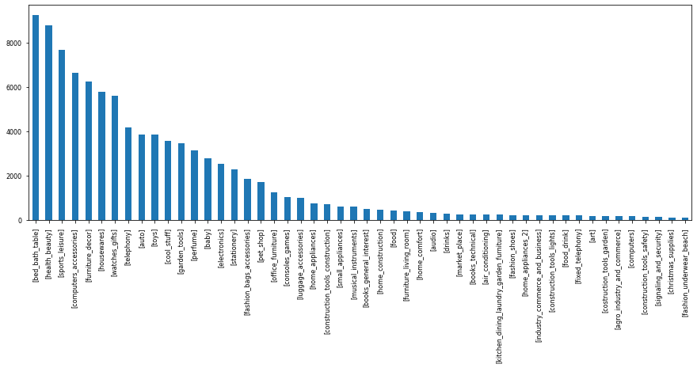

```python
# plt.style.use('fivethirtyeight') #sets the size of the charts
transactions.value_counts()[:50].plot(kind='bar', figsize=(15,5))
```

**Insight:**

1. The most common itemsets consist of a single item.
2. There's a long tail of categories that consist of infrequently purchased items.

```python
# Convert the pandas series to list of lists.
transactions = transactions.tolist()
```

### **Summarize final transaction data**

```python
len(transactions)
```

```
97256
```

```python
# Count number of unique item categories for each transaction.
counts = [len(transaction) for transaction in transactions]
```

```python
# Print median number of items in a transaction.
np.median(counts)
```

```
1.0
```

```python
# Print maximum number of items in a transaction.
np.max(counts)
```

```
3
```

## **Association Rules and Metrics**

```python
from mlxtend.preprocessing import TransactionEncoder

# Instantiate an encoder.
encoder = TransactionEncoder()

# Fit encoder to list of lists.
encoder.fit(transactions)

# Transform lists into one-hot encoded array.
onehot = encoder.transform(transactions)

# Convert array to pandas DataFrame.
onehot = pd.DataFrame(onehot, columns = encoder.columns_)
```

```python
onehot.head()
```

|  | agro_industry_and_commerce | air_conditioning | art | arts_and_crafts | audio | auto | baby | bed_bath_table | books_general_interest | books_imported | ... | security_and_services | signaling_and_security | small_appliances | small_appliances_home_oven_and_coffee | sports_leisure | stationery | tablets_printing_image | telephony | toys | watches_gifts |
| --- | --- | --- | --- | --- | --- | --- | --- | --- | --- | --- | --- | --- | --- | --- | --- | --- | --- | --- | --- | --- | --- |
| 0 | False | False | False | False | False | False | False | False | False | False | ... | False | False | False | False | False | False | False | False | False | False |
| 1 | False | False | False | False | False | False | False | False | False | False | ... | False | False | False | False | False | False | False | False | False | False |
| 2 | False | False | False | False | False | False | False | False | False | False | ... | False | False | False | False | False | False | False | False | False | False |
| 3 | False | False | False | False | False | False | False | False | False | False | ... | False | False | False | False | False | False | False | False | False | False |
| 4 | False | False | False | False | False | False | False | False | False | False | ... | False | False | False | False | False | False | False | False | False | False |

5 rows × 71 columns

```python
# Print support metric over all rows for each column.
onehot.mean(axis=0)
```

```
agro_industry_and_commerce    0.001871
air_conditioning              0.002601
art                           0.002077
arts_and_crafts               0.000236
audio                         0.003599
                                ...
stationery                    0.023762
tablets_printing_image        0.000812
telephony                     0.043175
toys                          0.039956
watches_gifts                 0.057827
Length: 71, dtype: float64
```

### **Compute the item count distribution over transactions**

```python
# Print distribution of item counts.
onehot.sum(axis=1).value_counts()
```

```
1    96530
2      711
3       15
dtype: int64
```

**Insight:**

- Only 726 transactions contain more than one item category. We may want to consider whether aggregation discards too many multi-item itemsets.

### **Create a column for an itemset with multiple items**

```python
# Add sports_leisure and health_beauty to DataFrame.
onehot['sports_leisure_health_beauty'] = onehot['sports_leisure'] & onehot['health_beauty']

# Print support value.
onehot['sports_leisure_health_beauty'].mean(axis = 0)
```

```
0.00014394998766142962
```

**Insight:**

- Only 0.014% of transactions contain a product from both the sports and leisure, and health and beauty categories. These are typically the type of numbers we will work with when we set pruning thresholds in the following section.

### **Aggregate the dataset further by combining product sub-categories**

```python
# Merge books_imported and books_technical.
onehot['books'] = onehot['books_imported'] | onehot['books_technical']

# Print support values for books, books_imported, and books_technical.
onehot[['books','books_imported','books_technical']].mean(axis=0)
```

```
books              0.003218
books_imported     0.000545
books_technical    0.002673
dtype: float64
```

### **Compute the confidence metric**

A high value of confidence indicates that the antecedent and consequent are associated and that the direction of the association runs from the antecedent to the consequent.

```python
# Joint support for sports_leisure and health_beauty.
joint_support = (onehot['sports_leisure'] & onehot['health_beauty']).mean()

# Confidence metric for sports_leisure to health_beauty.
joint_support / onehot['sports_leisure'].mean()
```

```
0.0018134715025906734
```

```python
# Confidence for health_beauty to sports_leisure.
joint_support / onehot['sports_leisure'].mean()
```

```
0.0018134715025906734
```

## **The Apriori Algorithm and Pruning**

The Apriori algorithm identifies frequent (high support) itemsets using something called the Apriori principle, which states that a superset that contains an infrequent item is also infrequent.

Pruning is the process of removing itemsets or association rules, typically based on the application of a metric threshold.

### **Applying the Apriori algorithm**

```python
from mlxtend.frequent_patterns import apriori

# Apply apriori with min support threshold of 0.01.
frequent_itemsets = apriori(onehot, min_support = 0.01)

frequent_itemsets
```

|  | support | itemsets |
| --- | --- | --- |
| 0 | 0.040070 | (5) |
| 1 | 0.029664 | (6) |
| 2 | 0.096827 | (7) |
| 3 | 0.068777 | (15) |
| 4 | 0.010920 | (16) |
| 5 | 0.037345 | (20) |
| 6 | 0.026219 | (27) |
| 7 | 0.019166 | (28) |
| 8 | 0.066310 | (40) |
| 9 | 0.036173 | (43) |
| 10 | 0.090853 | (44) |
| 11 | 0.060500 | (50) |
| 12 | 0.010632 | (53) |
| 13 | 0.013089 | (57) |
| 14 | 0.032512 | (59) |
| 15 | 0.017582 | (60) |
| 16 | 0.079378 | (65) |
| 17 | 0.023762 | (66) |
| 18 | 0.043175 | (68) |
| 19 | 0.039956 | (69) |
| 20 | 0.057827 | (70) |

```python
# Apply apriori with min support threshold of 0.001.
frequent_itemsets = apriori(onehot, min_support = 0.001, use_colnames = True)

frequent_itemsets
```

|  | support | itemsets |
| --- | --- | --- |
| 0 | 0.001871 | (agro_industry_and_commerce) |
| 1 | 0.002601 | (air_conditioning) |
| 2 | 0.002077 | (art) |
| 3 | 0.003599 | (audio) |
| 4 | 0.040070 | (auto) |
| 5 | 0.029664 | (baby) |
| 6 | 0.096827 | (bed_bath_table) |
| 7 | 0.005264 | (books_general_interest) |
| 8 | 0.002673 | (books_technical) |
| 9 | 0.001316 | (christmas_supplies) |
| 10 | 0.001861 | (computers) |
| 11 | 0.068777 | (computers_accessories) |
| 12 | 0.010920 | (consoles_games) |
| 13 | 0.007691 | (construction_tools_construction) |
| 14 | 0.002509 | (construction_tools_lights) |
| 15 | 0.001717 | (construction_tools_safety) |
| 16 | 0.037345 | (cool_stuff) |
| 17 | 0.001995 | (costruction_tools_garden) |
| 18 | 0.003054 | (drinks) |
| 19 | 0.026219 | (electronics) |
| 20 | 0.019166 | (fashion_bags_accessories) |
| 21 | 0.001152 | (fashion_male_clothing) |
| 22 | 0.002468 | (fashion_shoes) |
| 23 | 0.001244 | (fashion_underwear_beach) |
| 24 | 0.002231 | (fixed_telephony) |
| 25 | 0.004627 | (food) |
| 26 | 0.002334 | (food_drink) |
| 27 | 0.066310 | (furniture_decor) |
| 28 | 0.004339 | (furniture_living_room) |
| 29 | 0.036173 | (garden_tools) |
| 30 | 0.090853 | (health_beauty) |
| 31 | 0.007856 | (home_appliances) |
| 32 | 0.002406 | (home_appliances_2) |
| 33 | 0.004082 | (home_comfort) |
| 34 | 0.005038 | (home_construction) |
| 35 | 0.060500 | (housewares) |
| 36 | 0.002416 | (industry_commerce_and_business) |
| 37 | 0.002550 | (kitchen_dining_laundry_garden_furniture) |
| 38 | 0.010632 | (luggage_accessories) |
| 39 | 0.002879 | (market_place) |
| 40 | 0.006457 | (musical_instruments) |
| 41 | 0.013089 | (office_furniture) |
| 42 | 0.032512 | (perfume) |
| 43 | 0.017582 | (pet_shop) |
| 44 | 0.001439 | (signaling_and_security) |
| 45 | 0.006478 | (small_appliances) |
| 46 | 0.079378 | (sports_leisure) |
| 47 | 0.023762 | (stationery) |
| 48 | 0.043175 | (telephony) |
| 49 | 0.039956 | (toys) |
| 50 | 0.057827 | (watches_gifts) |
| 51 | 0.003218 | (books) |
| 52 | 0.002673 | (books, books_technical) |

**Insight:** Lowering the support threshold increased the number of itemsets returned and even yielded itemsets with more than one item.

```python
# Apply apriori with min support threshold of 0.00005.
frequent_itemsets = apriori(onehot, min_support = 0.00005, use_colnames = True)

frequent_itemsets
```

|  | support | itemsets |
| --- | --- | --- |
| 0 | 0.001871 | (agro_industry_and_commerce) |
| 1 | 0.002601 | (air_conditioning) |
| 2 | 0.002077 | (art) |
| 3 | 0.000236 | (arts_and_crafts) |
| 4 | 0.003599 | (audio) |
| ... | ... | ... |
| 108 | 0.000051 | (stationery, luggage_accessories) |
| 109 | 0.000051 | (watches_gifts, sports_leisure) |
| 110 | 0.000144 | (sports_leisure_health_beauty, sports_leisure) |
| 111 | 0.000062 | (stationery, toys) |
| 112 | 0.000144 | (sports_leisure_health_beauty, health_beauty, ... |

113 rows × 2 columns

**Observation:** Notice how low we must set the support threshold (0.005%) to return a high number of itemsets with more than one item.

```python
# Apply apriori algorithm to data with a two-item limit.
frequent_itemsets = apriori(onehot, min_support = 0.00005, max_len = 2, use_colnames = True)
```

### **Computing association rules from Apriori output**

```python
from mlxtend.frequent_patterns import association_rules

# Recover association rules using support and a minimum threshold of 0.0001.
rules = association_rules(frequent_itemsets, metric = 'support', min_threshold = 0.0001)

# Print rules header.
rules.head()
```

|  | antecedents | consequents | antecedent support | consequent support | support | confidence | lift | leverage | conviction |
| --- | --- | --- | --- | --- | --- | --- | --- | --- | --- |
| 0 | (baby) | (bed_bath_table) | 0.029664 | 0.096827 | 0.000175 | 0.005893 | 0.060856 | -0.002697 | 0.908527 |
| 1 | (bed_bath_table) | (baby) | 0.096827 | 0.029664 | 0.000175 | 0.001805 | 0.060856 | -0.002697 | 0.972091 |
| 2 | (baby) | (cool_stuff) | 0.029664 | 0.037345 | 0.000206 | 0.006932 | 0.185633 | -0.000902 | 0.969375 |
| 3 | (cool_stuff) | (baby) | 0.037345 | 0.029664 | 0.000206 | 0.005507 | 0.185633 | -0.000902 | 0.975709 |
| 4 | (baby) | (furniture_decor) | 0.029664 | 0.066310 | 0.000123 | 0.004159 | 0.062728 | -0.001844 | 0.937590 |

### **Pruning association rules**

```python
# Recover association rules using confidence threshold of 0.01.
rules = association_rules(frequent_itemsets, metric = 'confidence', min_threshold = 0.01)

rules
```

|  | antecedents | consequents | antecedent support | consequent support | support | confidence | lift | leverage | conviction |
| --- | --- | --- | --- | --- | --- | --- | --- | --- | --- |
| 0 | (art) | (furniture_decor) | 0.002077 | 0.066310 | 0.000051 | 0.024752 | 0.373287 | -0.000086 | 0.957388 |
| 1 | (audio) | (watches_gifts) | 0.003599 | 0.057827 | 0.000062 | 0.017143 | 0.296452 | -0.000146 | 0.958606 |
| 2 | (furniture_decor) | (bed_bath_table) | 0.066310 | 0.096827 | 0.000720 | 0.010854 | 0.112101 | -0.005701 | 0.913084 |
| 3 | (home_comfort) | (bed_bath_table) | 0.004082 | 0.096827 | 0.000442 | 0.108312 | 1.118618 | 0.000047 | 1.012881 |
| 4 | (books_imported) | (books) | 0.000545 | 0.003218 | 0.000545 | 1.000000 | 310.722045 | 0.000543 | inf |
| 5 | (books) | (books_imported) | 0.003218 | 0.000545 | 0.000545 | 0.169329 | 310.722045 | 0.000543 | 1.203190 |
| 6 | (books) | (books_technical) | 0.003218 | 0.002673 | 0.002673 | 0.830671 | 310.722045 | 0.002665 | 5.889872 |
| 7 | (books_technical) | (books) | 0.002673 | 0.003218 | 0.002673 | 1.000000 | 310.722045 | 0.002665 | inf |
| 8 | (construction_tools_lights) | (furniture_decor) | 0.002509 | 0.066310 | 0.000113 | 0.045082 | 0.679872 | -0.000053 | 0.977770 |
| 9 | (furniture_living_room) | (furniture_decor) | 0.004339 | 0.066310 | 0.000072 | 0.016588 | 0.250155 | -0.000216 | 0.949439 |
| 10 | (home_comfort) | (furniture_decor) | 0.004082 | 0.066310 | 0.000062 | 0.015113 | 0.227921 | -0.000209 | 0.948018 |
| 11 | (home_construction) | (furniture_decor) | 0.005038 | 0.066310 | 0.000134 | 0.026531 | 0.400103 | -0.000200 | 0.959137 |
| 12 | (home_construction) | (garden_tools) | 0.005038 | 0.036173 | 0.000072 | 0.014286 | 0.394932 | -0.000110 | 0.977796 |
| 13 | (sports_leisure_health_beauty) | (health_beauty) | 0.000144 | 0.090853 | 0.000144 | 1.000000 | 11.006790 | 0.000131 | inf |
| 14 | (sports_leisure_health_beauty) | (sports_leisure) | 0.000144 | 0.079378 | 0.000144 | 1.000000 | 12.597927 | 0.000133 | inf |

```python
# Select rules with a consequent support above 0.095.
rules = rules[rules['consequent support'] > 0.095]

rules
```

|  | antecedents | consequents | antecedent support | consequent support | support | confidence | lift | leverage | conviction |
| --- | --- | --- | --- | --- | --- | --- | --- | --- | --- |
| 2 | (furniture_decor) | (bed_bath_table) | 0.066310 | 0.096827 | 0.000720 | 0.010854 | 0.112101 | -0.005701 | 0.913084 |
| 3 | (home_comfort) | (bed_bath_table) | 0.004082 | 0.096827 | 0.000442 | 0.108312 | 1.118618 | 0.000047 | 1.012881 |

### **The leverage metric**

```python
# Select rules with leverage higher than 0.0.
rules = rules[rules['leverage'] > 0.0]

rules
```

|  | antecedents | consequents | antecedent support | consequent support | support | confidence | lift | leverage | conviction |
| --- | --- | --- | --- | --- | --- | --- | --- | --- | --- |
| 3 | (home_comfort) | (bed_bath_table) | 0.004082 | 0.096827 | 0.000442 | 0.108312 | 1.118618 | 0.000047 | 1.012881 |

### **Visualizing patterns in metrics**

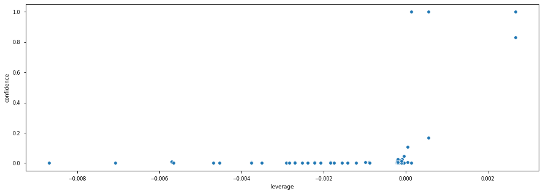

```python
rules = association_rules(frequent_itemsets, metric = 'support', min_threshold = 0.000001)

# Plot leverage against confidence.
plt.figure(figsize=(15,5))
sns.scatterplot(x="leverage", y="confidence", data=rules)
```

**Insight**:

- Leverage and confidence contain some of the same information about the strength of an association.